# Generating final model predictions after relativizing

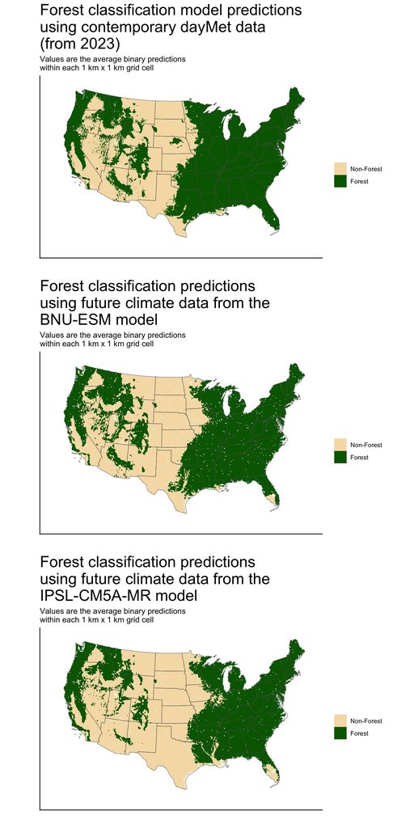

```r
## Plot predictions with contemporary data
# make into a raster
plotObs <- preds_byHand %>%
         #drop_na(paste(response)) %>%
  #slice_sample(n = 5e4) %>%
  terra::vect(#geom = c("Lon", "Lat")
    ) %>%
  terra::set.crs(crs(test_rastTemp)) %>%
  terra::rasterize(y = test_rastTemp,
                   field = "pred_binary",
                   fun = mean, na.rm = TRUE)

# get the extent of this particular raster, and crop≠ it accordingly
tempExt <- crds(plotObs, na.rm = TRUE)

plotObs_2 <- plotObs %>%
  crop(ext(min(tempExt[,1]), max(tempExt[,1]),
           min(tempExt[,2]), max(tempExt[,2]))
       )

map_ecoRegion_current <-
  ggplot() +
geom_raster(data = plotObs_2, aes(x = x,
                   y = y,
                   fill = as.character(mean)), maxcell = 5e+10) +
  geom_sf(data=cropped_states %>% st_transform(crs = st_crs(test_rast)) %>% st_crop(st_bbox(plotObs_2)) ,fill=NA ) +
 xlim(-2150000, 2510000) +
 ylim(-2005000, 1000000) +
  coord_sf(datum = st_crs(test_rastTemp)) +
  scale_fill_manual(name = "",
                     values = c("wheat", "darkgreen"),
                     labels = c("Non-Forest", "Forest"),
                    na.translate = FALSE) +
             theme(
                   axis.text = element_blank(),
                   strip.text = element_text(size = 15),
                   title = element_text(size = 18),
                   axis.ticks = element_blank()) +
  labs(title = c("Forest classification model predictions \nusing contemporary dayMet data \n(from 2023)"),
     subtitle = c("Values are the average binary predictions \nwithin each 1 km x 1 km grid cell"), x = "", y = "")

# for future v1
plotObs_future1 <- preds_future1_byHand %>%
         #drop_na(paste(response)) %>%
  #slice_sample(n = 5e4) %>%
  terra::vect(geom = c("x", "y")) %>%
  terra::set.crs(crs(test_rast)) %>%
  terra::rasterize(y = test_rast,
                   field = "pred_binary",
                   fun = mean, na.rm = TRUE)


# get the extent of this particular raster, and crop it accordingly
plotObs_future1_2 <- plotObs_future1 %>%
  crop(ext(min(tempExt[,1]), max(tempExt[,1]),
           min(tempExt[,2]), max(tempExt[,2]))
       )

map_ecoRegion_future1 <-
  ggplot() +
geom_raster(data = plotObs_future1_2, aes(x = x,
                   y = y,
                   fill = as.character(mean)), maxcell = 5e+12) +
  geom_sf(data=cropped_states %>% st_transform(crs = st_crs(test_rast)) %>% st_crop(st_bbox(plotObs_2)) ,fill=NA ) +
 xlim(-2150000, 2510000) +
 ylim(-2005000, 1000000) +
  coord_sf(datum = st_crs(test_rastTemp)) +
  scale_fill_manual(name = "",
                     values = c("wheat", "darkgreen"),
                     labels = c("Non-Forest", "Forest"),
                    na.translate = FALSE) +

             theme(
                   axis.text = element_blank(),
                   strip.text = element_text(size = 15),
                   title = element_text(size = 18),
                   axis.ticks = element_blank()) +
 labs(title = c("Forest classification predictions \nusing future climate data from the \nBNU-ESM model"),
     subtitle = c("Values are the average binary predictions \nwithin each 1 km x 1 km grid cell"), x = "", y = ""
     )


# for future v2
plotObs_future2 <- preds_future2_byHand %>%
         #drop_na(paste(response)) %>%
  #slice_sample(n = 5e4) %>%
  terra::vect(geom = c("x", "y")) %>%
  terra::set.crs(crs(test_rast)) %>%
  terra::rasterize(y = test_rast,
                   field = "pred_binary",
                   fun = mean, na.rm = TRUE)

# get the extent of this particular raster, and crop it accordingly
plotObs_future2_2 <- plotObs_future2 %>%
  crop(ext(min(tempExt[,1]), max(tempExt[,1]),
           min(tempExt[,2]), max(tempExt[,2]))
       )

map_ecoRegion_future2 <-
  ggplot() +
geom_raster(data = plotObs_future2_2, aes(x = x,
                   y = y,
                   fill = as.character(mean)), maxcell = 5e+10) +
  geom_sf(data=cropped_states %>% st_transform(crs = st_crs(test_rast)) %>% st_crop(st_bbox(plotObs_2)) ,fill=NA ) +
 xlim(-2150000, 2510000) +
 ylim(-2005000, 1000000) +
  coord_sf(datum = st_crs(test_rastTemp)) +
  scale_fill_manual(name = "",
                     values = c("wheat", "darkgreen"),
                     labels = c("Non-Forest", "Forest"),
                    na.translate = FALSE) +
             theme(
                   axis.text = element_blank(),
                   strip.text = element_text(size = 15),
                   title = element_text(size = 18),
                   axis.ticks = element_blank()) +
labs(title = c("Forest classification predictions \nusing future climate data from the \nIPSL-CM5A-MR model"),
     subtitle = c("Values are the average binary predictions \nwithin each 1 km x 1 km grid cell"), x = "", y = ""
     )


## Plot the maps together
  ggarrange(map_ecoRegion_current, map_ecoRegion_future1, map_ecoRegion_future2, nrow = 3) #%>%
```

```r
  #annotate_figure(fig.lab = "Model Predictions of Forest Classification with Contemporary and Forecasted Climate Data", fig.lab.size = 20,
                 # )
```

Below is a map of the ‘scaling factor’ that we use to make predictions of total tree cover CONUS-wide. If the model-predicted probability of forest is high or low, then we take the predictions of total tree cover for forest and non-forest at face value. However, if the model predicted forest probability is near the threshold for making the predictions binary, we interpolate the continuous P(Forest) predictions within this buffer to generate a continuous “scaling factor” that we use to mix the predictions of total tree cover from the forest and non-forest model together.

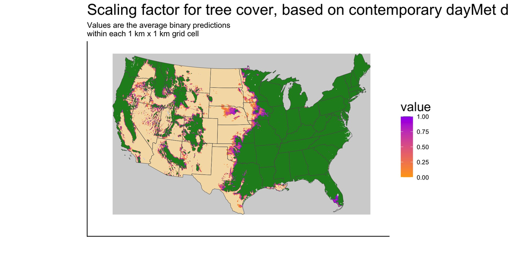

```r
# figure of transformed P(Forest)
plotObs <- preds_byHand %>%
         #drop_na(paste(response)) %>%
  #slice_sample(n = 5e4) %>%
  terra::vect(#geom = c("Lon", "Lat")
    ) %>%
  terra::set.crs(crs(test_rastTemp)) %>%
  terra::rasterize(y = test_rastTemp,
                   field = "pred_contNew",
                   fun = mean, na.rm = TRUE)
# get the extent of this particular raster, and crop≠ it accordingly
plotObs_2 <- plotObs %>%
  crop(ext(min(tempExt[,1]), max(tempExt[,1]),
           min(tempExt[,2]), max(tempExt[,2]))
       )

map_ecoRegion_current_Transformed<- ggplot() +
geom_spatraster(data = plotObs_2, maxcell = 5e+10) +
  geom_sf(data=cropped_states %>% st_transform(crs = st_crs(test_rast)) %>% st_crop(st_bbox(plotObs_2)) ,fill=NA ) +
 xlim(-2150000, 2510000) +
 ylim(-2005000, 1000000) +
  coord_sf(datum = st_crs(test_rastTemp)) +
 scale_fill_gradientn(
                                             colors = c("wheat", "orange", "purple", "forestgreen"),
                                             values = c(0, 1e-10, 0.99999, 1),
                                             limits = c(0,1),
                                             na.value = "lightgrey"
                                             ) +
             theme(
                   axis.text = element_blank(),
                   strip.text = element_text(size = 15),
                   title = element_text(size = 18),
                   axis.ticks = element_blank()) +
labs(title = c("Scaling factor for tree cover, based on contemporary dayMet data (2023)"),
     subtitle = c("Values are the average binary predictions \nwithin each 1 km x 1 km grid cell"), x = "", y = ""
     )


## future 1
# figure of transformed P(Forest)
plotObs <- preds_future1_byHand %>%
         #drop_na(paste(response)) %>%
  #slice_sample(n = 5e4) %>%
  terra::vect(#geom = c("Lon", "Lat")
    ) %>%
  terra::set.crs(crs(test_rast)) %>%
  terra::rasterize(y = test_rast,
                   field = "pred_contNew",
                   fun = mean, na.rm = TRUE)
# get the extent of this particular raster, and crop≠ it accordingly
plotObs_2 <- plotObs %>%
  crop(ext(min(tempExt[,1]), max(tempExt[,1]),
           min(tempExt[,2]), max(tempExt[,2]))
       )


map_ecoRegion_future1_Transformed<- ggplot() +
geom_spatraster(data = plotObs_2, maxcell = 5e+10) +
  geom_sf(data=cropped_states %>% st_transform(crs = st_crs(test_rast)) %>% st_crop(st_bbox(plotObs_2)) ,fill=NA ) +
 xlim(-2150000, 2510000) +
 ylim(-2005000, 1000000) +
  coord_sf(datum = st_crs(test_rastTemp)) +
 scale_fill_gradientn(
                                             colors = c("wheat", "orange", "purple", "forestgreen"),
                                             values = c(0, 1e-10, 0.99999, 1),
                                             limits = c(0,1),
                                             na.value = "lightgrey"
                                             ) +
             theme(
                   axis.text = element_blank(),
                   strip.text = element_text(size = 15),
                   title = element_text(size = 18),
                   axis.ticks = element_blank()) +
labs(title = c("Scaling factor for tree cover, based on future climate data from the \nBNU-ESM model"),
     subtitle = c("Values are the average binary predictions \nwithin each 12 km x 12 km grid cell"), x = "", y = ""
     )

## future 2
# figure of transformed P(Forest)
plotObs <- preds_future2_byHand %>%
         #drop_na(paste(response)) %>%
  #slice_sample(n = 5e4) %>%
  terra::vect(#geom = c("Lon", "Lat")
    ) %>%
  terra::set.crs(crs(test_rast)) %>%
  terra::rasterize(y = test_rast,
                   field = "pred_contNew",
                   fun = mean, na.rm = TRUE)
# get the extent of this particular raster, and crop≠ it accordingly
plotObs_2 <- plotObs %>%
  crop(ext(min(tempExt[,1]), max(tempExt[,1]),
           min(tempExt[,2]), max(tempExt[,2]))
       )


map_ecoRegion_future2_Transformed<- ggplot() +
geom_spatraster(data = plotObs_2, maxcell = 5e+10) +
  geom_sf(data=cropped_states %>% st_transform(crs = st_crs(test_rast)) %>% st_crop(st_bbox(plotObs_2)) ,fill=NA ) +
 xlim(-2150000, 2510000) +
 ylim(-2005000, 1000000) +
  coord_sf(datum = st_crs(test_rastTemp)) +
 scale_fill_gradientn(
                                             colors = c("wheat", "orange", "purple", "forestgreen"),
                                             values = c(0, 1e-10, 0.99999, 1),
                                             limits = c(0,1),
                                             na.value = "lightgrey"
                                             ) +
             theme(
                   axis.text = element_blank(),
                   strip.text = element_text(size = 15),
                   title = element_text(size = 18),
                   axis.ticks = element_blank()) +
labs(title = c("Scaling factor for tree cover, based on future climate data from the \nIPSL-CM5A-MR model"),
     subtitle = c("Values are the average binary predictions \nwithin each 12 km x 12 km grid cell"), x = "", y = ""
     )

(map_ecoRegion_current_Transformed)
```

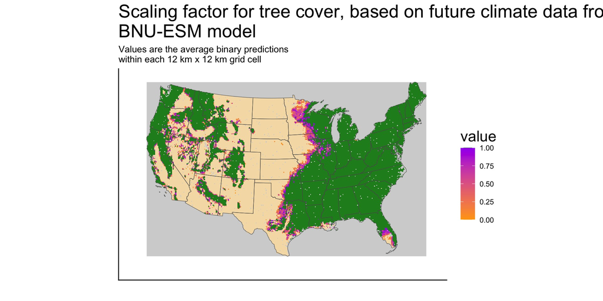

```r
(map_ecoRegion_future1_Transformed)
```

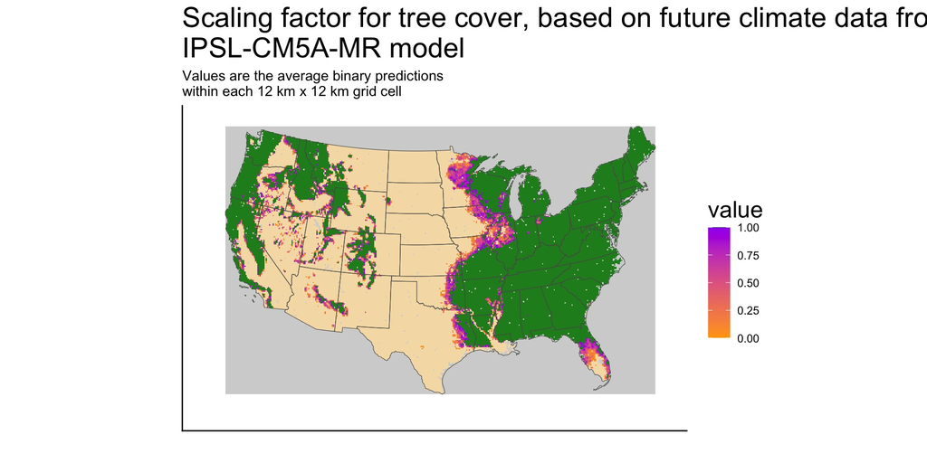

```r
(map_ecoRegion_future2_Transformed)
```

Now, we show the predictions from the model that predicts whether a location has *no* trees. These predictions are combined with the predictions from the forest model, such that only locations that the forest model predicts to be un-forested can then be predicted to be un-treed.

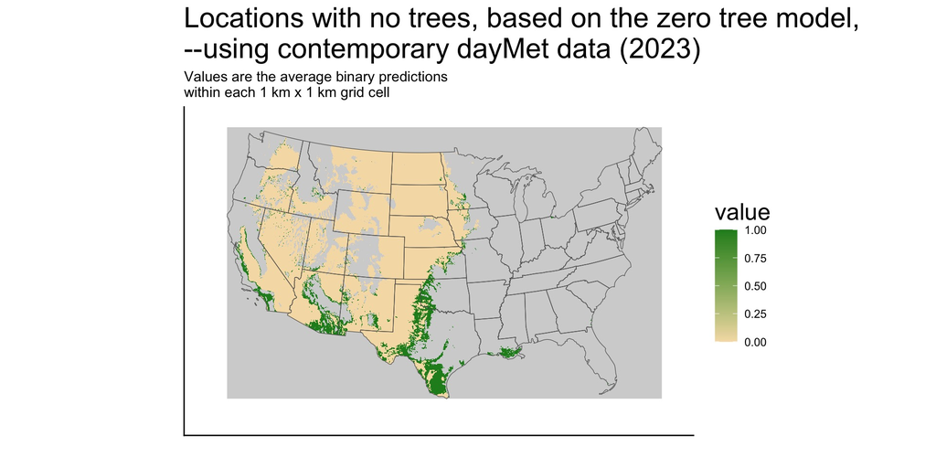

```r
# read in the model object
# we use the oneSELambda model, since the predictions are very similar to the best lambda model
zeroTreeMod <- readRDS("./models/yesOrNoTrees_oneSELambdaGLM_10.rds")
# get threshold for making model predictions binary
zeroTreeMod_threshold <- readRDS("./models/yesOrNoTreeModel_ModelPrevalence.rds")

# predict w/ contemporary data
preds_byHand <- preds_byHand %>%
  mutate(zeroTree_pred = predict(object = zeroTreeMod, climDatPred, type = "response"),
         zeroTree_binary = zeroTree_pred) %>%
  # make predictions of zero tree binary
  mutate(zeroTree_binary = replace(zeroTree_binary, zeroTree_binary > zeroTreeMod_threshold, 1),
         zeroTree_binary = replace(zeroTree_binary, zeroTree_binary <= zeroTreeMod_threshold, 0)) %>%
  # now, get predictions for locations that the forest model predicts to be forested
  mutate(zeroTree_nonForest = zeroTree_binary) %>%
  mutate(zeroTree_nonForest = replace(zeroTree_nonForest, pred_binary == 1, NA))

# predict w/ future 1 data
preds_future1_byHand <- preds_future1_byHand %>%
  mutate(zeroTree_pred = predict(object = zeroTreeMod, forecastClimSoilsDatPred_1, type = "response"),
         zeroTree_binary = zeroTree_pred) %>%
  mutate(zeroTree_binary = replace(zeroTree_binary, zeroTree_binary > zeroTreeMod_threshold, 1),
         zeroTree_binary = replace(zeroTree_binary, zeroTree_binary <= zeroTreeMod_threshold, 0)) %>%
  # now, get predictions for locations that the forest model predicts to be forested
  mutate(zeroTree_nonForest = zeroTree_binary) %>%
  mutate(zeroTree_nonForest = replace(zeroTree_nonForest, pred_binary == 1, NA))


# predict w/ future 2 data
preds_future2_byHand <- preds_future2_byHand %>%
  mutate(zeroTree_pred = predict(object = zeroTreeMod, forecastClimSoilsDatPred_2, type = "response"),
         zeroTree_binary = zeroTree_pred) %>%
  mutate(zeroTree_binary = replace(zeroTree_binary, zeroTree_binary > zeroTreeMod_threshold, 1),
         zeroTree_binary = replace(zeroTree_binary, zeroTree_binary <= zeroTreeMod_threshold, 0)) %>%
  # now, get predictions for locations that the forest model predicts to be forested
  mutate(zeroTree_nonForest = zeroTree_binary) %>%
  mutate(zeroTree_nonForest = replace(zeroTree_nonForest, pred_binary == 1, NA))


# figure of transformed P(Forest)
plotObs <- preds_byHand %>%
         #drop_na(paste(response)) %>%
  #slice_sample(n = 5e4) %>%
  terra::vect(#geom = c("Lon", "Lat")
    ) %>%
  terra::set.crs(crs(test_rastTemp)) %>%
  terra::rasterize(y = test_rastTemp,
                   field = "zeroTree_nonForest",
                   fun = mean, na.rm = TRUE)
# get the extent of this particular raster, and crop≠ it accordingly
plotObs_2 <- plotObs %>%
  crop(ext(min(tempExt[,1]), max(tempExt[,1]),
           min(tempExt[,2]), max(tempExt[,2]))
       )

map_zeroTreePred_current <- ggplot() +
geom_spatraster(data = plotObs_2, maxcell = 5e+10) +
  geom_sf(data=cropped_states %>% st_transform(crs = st_crs(test_rast)) %>% st_crop(st_bbox(plotObs_2)) ,fill=NA ) +
 xlim(-2150000, 2510000) +
 ylim(-2005000, 1000000) +
  coord_sf(datum = st_crs(test_rastTemp)) +
 scale_fill_gradientn(
                                             colors = c("wheat", "forestgreen"),
                                             values = c(0, 1),
                                             limits = c(0,1),
                                             na.value = "lightgrey"
                                             ) +
             theme(
                   axis.text = element_blank(),
                   strip.text = element_text(size = 15),
                   title = element_text(size = 18),
                   axis.ticks = element_blank()) +
labs(title = c("Locations with no trees, based on the zero tree model,\n--using contemporary dayMet data (2023)"),
     subtitle = c("Values are the average binary predictions \nwithin each 1 km x 1 km grid cell"), x = "", y = ""
     )


## future 1
# figure of transformed P(Forest)
plotObs <- preds_future1_byHand %>%
         #drop_na(paste(response)) %>%
  #slice_sample(n = 5e4) %>%
  terra::vect(#geom = c("Lon", "Lat")
    ) %>%
  terra::set.crs(crs(test_rast)) %>%
  terra::rasterize(y = test_rast,
                   field = "zeroTree_nonForest",
                   fun = mean, na.rm = TRUE)
# get the extent of this particular raster, and crop≠ it accordingly
plotObs_2 <- plotObs %>%
  crop(ext(min(tempExt[,1]), max(tempExt[,1]),
           min(tempExt[,2]), max(tempExt[,2]))
       )


map_zeroTreePred_future1 <- ggplot() +
geom_spatraster(data = plotObs_2, maxcell = 5e+10) +
  geom_sf(data=cropped_states %>% st_transform(crs = st_crs(test_rast)) %>% st_crop(st_bbox(plotObs_2)) ,fill=NA ) +
 xlim(-2150000, 2510000) +
 ylim(-2005000, 1000000) +
  coord_sf(datum = st_crs(test_rastTemp)) +
 scale_fill_gradientn(
                                             colors = c("wheat", "forestgreen"),
                                             values = c(0, 1),
                                             limits = c(0,1),
                                             na.value = "lightgrey"
                                             ) +
             theme(
                   axis.text = element_blank(),
                   strip.text = element_text(size = 15),
                   title = element_text(size = 18),
                   axis.ticks = element_blank()) +
labs(title = c("Locations with no trees, based on the zero tree model,\n--using future climate data from the BNU-ESM model"),
     subtitle = c("Values are the average binary predictions \nwithin each 1 km x 1 km grid cell"), x = "", y = ""
     )

## future 2
# figure of transformed P(Forest)
plotObs <- preds_future2_byHand %>%
         #drop_na(paste(response)) %>%
  #slice_sample(n = 5e4) %>%
  terra::vect(#geom = c("Lon", "Lat")
    ) %>%
  terra::set.crs(crs(test_rast)) %>%
  terra::rasterize(y = test_rast,
                   field = "zeroTree_nonForest",
                   fun = mean, na.rm = TRUE)
# get the extent of this particular raster, and crop≠ it accordingly
plotObs_2 <- plotObs %>%
  crop(ext(min(tempExt[,1]), max(tempExt[,1]),
           min(tempExt[,2]), max(tempExt[,2]))
       )


map_zeroTreePred_future2 <- ggplot() +
geom_spatraster(data = plotObs_2, maxcell = 5e+10) +
  geom_sf(data=cropped_states %>% st_transform(crs = st_crs(test_rast)) %>% st_crop(st_bbox(plotObs_2)) ,fill=NA ) +
 xlim(-2150000, 2510000) +
 ylim(-2005000, 1000000) +
  coord_sf(datum = st_crs(test_rastTemp)) +
 scale_fill_gradientn(
                                             colors = c("wheat", "forestgreen"),
                                             values = c(0, 1),
                                             limits = c(0,1),
                                             na.value = "lightgrey"
                                             ) +
             theme(
                   axis.text = element_blank(),
                   strip.text = element_text(size = 15),
                   title = element_text(size = 18),
                   axis.ticks = element_blank()) +
labs(title = c("Locations with no trees, based on the zero tree model,\n--using future climate data from the IPSL-CM5A-MR model"),
     subtitle = c("Values are the average binary predictions \nwithin each 1 km x 1 km grid cell"), x = "", y = ""
     )


(map_zeroTreePred_current)
```

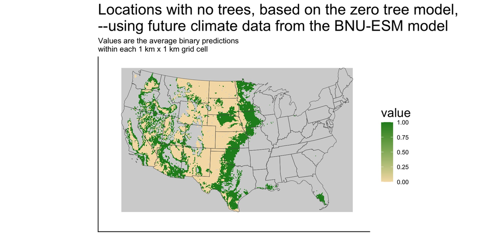

```r
(map_zeroTreePred_future1)
```

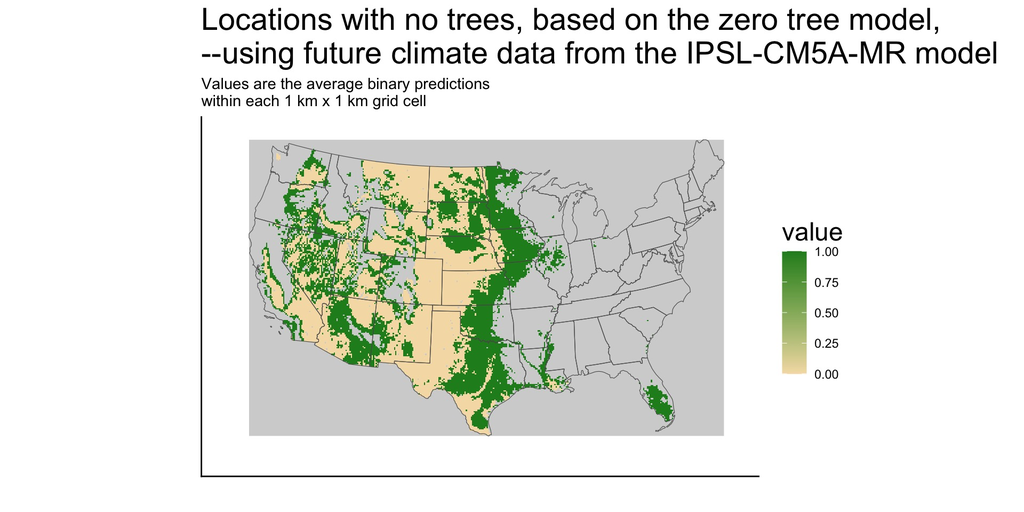

```r
(map_zeroTreePred_future2)
```